# Preprocessing

- Preprocessing GPS data
- Preprocessing LBSN (social media) data

```python
import skmob
from skmob.utils import constants
from skmob.utils import utils

from geopy.distance import distance
import pandas as pd
import numpy as np
```

# Preprocessing GPS data

## Load data from file

Subset of data from the Geolife project, available [here](https://www.microsoft.com/en-us/download/details.aspx?id=52367).

```python
# %%time
tdf = skmob.TrajDataFrame.from_file('./data/geolife_sample.txt.gz')
tdf[:4]
```

|  | lat | lng | datetime | uid |
| --- | --- | --- | --- | --- |
| 0 | 39.984094 | 116.319236 | 2008-10-23 05:53:05 | 1 |
| 1 | 39.984198 | 116.319322 | 2008-10-23 05:53:06 | 1 |
| 2 | 39.984224 | 116.319402 | 2008-10-23 05:53:11 | 1 |
| 3 | 39.984211 | 116.319389 | 2008-10-23 05:53:16 | 1 |

```python
tdf.dtypes
```

```
lat                float64
lng                float64
datetime    datetime64[ns]
uid                  int64
dtype: object
```

```python
tdf.crs
```

```
{'init': 'epsg:4326'}
```

```python
tdf.parameters
```

```
{'from_file': './data/geolife_sample.txt.gz'}
```

#### Convert `datetime` column from original timezone `'GMT'` to local timezione `'Asia/Shanghai'`

```python
tdf.timezone_conversion(from_timezone='GMT', to_timezone='Asia/Shanghai')
tdf[:4]
```

|  | lat | lng | uid | datetime |
| --- | --- | --- | --- | --- |
| 0 | 39.984094 | 116.319236 | 1 | 2008-10-23 13:53:05 |
| 1 | 39.984198 | 116.319322 | 1 | 2008-10-23 13:53:06 |
| 2 | 39.984224 | 116.319402 | 1 | 2008-10-23 13:53:11 |
| 3 | 39.984211 | 116.319389 | 1 | 2008-10-23 13:53:16 |

#### Visualise the raw trajectories on a map

Plot the trajectories of `max_users=2` users.

To save memory, each trajectory is downsampled so that at most `max_points=2000` points are plotted.

```python
map_f = tdf.plot_trajectory(max_users=2, max_points=2000) #, tiles='Stamen Toner') # try this for a b/w map
map_f
# map_f.save('./raw_trajectory.html') # Save plot to html file
```

[interactive chart not shown]

Plot the first 10k points of the user 1's trajectory

```python
tdf[tdf['uid'] == 1][:10000].plot_trajectory(weight=3, max_points=None)
```

[interactive chart not shown]

## Filtering

Filter out all points with speed higher than `max_speed` km/h from the previous point.

```python
from skmob.preprocessing import filtering
```

```python
tdf.parameters
```

```
{'from_file': './data/geolife_sample.txt.gz'}
```

```python
ftdf = filtering.filter(tdf, max_speed_kmh=500.)
```

```python
ftdf.parameters
```

```
{'from_file': './data/geolife_sample.txt.gz',
 'filter': {'function': 'filter',
  'max_speed_kmh': 500.0,
  'include_loops': False,
  'speed_kmh': 5.0,
  'max_loop': 6,
  'ratio_max': 0.25}}
```

```python
ftdf[:4]
```

|  | lat | lng | uid | datetime |
| --- | --- | --- | --- | --- |
| 0 | 39.984094 | 116.319236 | 1 | 2008-10-23 13:53:05 |
| 1 | 39.984198 | 116.319322 | 1 | 2008-10-23 13:53:06 |
| 2 | 39.984224 | 116.319402 | 1 | 2008-10-23 13:53:11 |
| 3 | 39.984211 | 116.319389 | 1 | 2008-10-23 13:53:16 |

Very few points have been filtered.

```python
print('Points of the raw trajectory: %s'%len(tdf))
print('Points of the filtered trajectory: %s'%len(ftdf))
```

```
Points of the raw trajectory: 217653
Points of the filtered trajectory: 217599
```

## Compression

Reduce the number of points of the trajectory, preserving the structure.

Merge together all points that are closer than `spatial_radius_km=0.2` kilometers from each other.

```python
from skmob.preprocessing import compression
```

```python
ctdf = compression.compress(ftdf, spatial_radius_km=0.2)
ctdf[:4]
```

|  | lat | lng | uid | datetime |
| --- | --- | --- | --- | --- |
| 0 | 39.984302 | 116.320730 | 1 | 2008-10-23 13:53:05 |
| 1 | 39.982115 | 116.321225 | 1 | 2008-10-23 13:56:06 |
| 2 | 39.979737 | 116.321564 | 1 | 2008-10-23 13:57:03 |
| 3 | 39.979672 | 116.323778 | 1 | 2008-10-23 13:59:05 |

```python
ctdf.parameters
```

```
{'from_file': './data/geolife_sample.txt.gz',
 'filter': {'function': 'filter',
  'max_speed_kmh': 500.0,
  'include_loops': False,
  'speed_kmh': 5.0,
  'max_loop': 6,
  'ratio_max': 0.25},
 'compress': {'function': 'compress', 'spatial_radius_km': 0.2}}
```

The compressed trajectory has only a small fraction of the points of the filtered trajectory.

```python
print('Points of the filtered trajectory: %s'%len(ftdf))
print('Points of the compressed trajectory: %s'%len(ctdf))
```

```
Points of the filtered trajectory: 217599
Points of the compressed trajectory: 6278
```

#### Visualise the filtered and compressed trajectories

Show the first 10000 points of the trajectory of the first user.

```python
end_time = ftdf.iloc[10000]['datetime']

map_f = ftdf[ftdf['datetime'] < end_time].plot_trajectory(max_users=1, weight=5, \
                                            opacity=0.5, start_end_markers=False)

ctdf[ctdf['datetime'] < end_time].plot_trajectory(max_users=1, map_f=map_f, \
                                                  start_end_markers=False)
```

[interactive chart not shown]

## Stop detection

Identify locations where the user spent at least `minutes_for_a_stop` minutes within a distance `spatial_radius_km` $\times$ `stop_radius_factor`, from a given point.

A new column `leaving_datetime` is added, indicating the time when the user departs from the stop.

```python
from skmob.preprocessing import detection
```

```python
stdf = detection.stops(ctdf, stop_radius_factor=0.5, \
            minutes_for_a_stop=20.0, spatial_radius_km=0.2,
                       leaving_time=True)
stdf[:4]
```

|  | lat | lng | uid | datetime | leaving_datetime |
| --- | --- | --- | --- | --- | --- |
| 0 | 39.978253 | 116.327275 | 1 | 2008-10-23 14:01:05 | 2008-10-23 18:32:53 |
| 1 | 40.013819 | 116.306532 | 1 | 2008-10-23 19:10:09 | 2008-10-24 07:46:02 |
| 2 | 39.978987 | 116.326686 | 1 | 2008-10-24 08:10:39 | 2008-10-24 09:48:57 |
| 3 | 39.981316 | 116.310181 | 1 | 2008-10-24 09:56:47 | 2008-10-24 11:21:09 |

```python
stdf.parameters
```

```
{'from_file': './data/geolife_sample.txt.gz',
 'filter': {'function': 'filter',
  'max_speed_kmh': 500.0,
  'include_loops': False,
  'speed_kmh': 5.0,
  'max_loop': 6,
  'ratio_max': 0.25},
 'compress': {'function': 'compress', 'spatial_radius_km': 0.2},
 'detect': {'function': 'stops',
  'stop_radius_factor': 0.5,
  'minutes_for_a_stop': 20.0,
  'spatial_radius_km': 0.2,
  'leaving_time': True,
  'no_data_for_minutes': 1000000000000.0,
  'min_speed_kmh': None}}
```

#### Visualise the compressed trajectory and the stops

Click on the stop markers to see a pop up with:

- User ID
- Coordinates of the stop (click to see the location on Google maps)
- Arrival time
- Departure time

```python
map_f = ctdf.plot_trajectory(max_points=1000, hex_color=-1, start_end_markers=False)
stdf.plot_stops(map_f=map_f, hex_color=-1)
```

[interactive chart not shown]

## Clustering stops

Stops are clustered by spatial proximity using DBSCAN.

The new column `cluster` is added to the Stops TrajectoryDataFrame, where the value correspond to the cluster ID each stop belong to.

Clusters IDs are integers (0, 1, ...): 0 is the most visited cluster, 1 is the second most visited, ...

```python
from skmob.preprocessing import clustering
```

```python
cstdf = clustering.cluster(stdf, cluster_radius_km=0.1, min_samples=1)
cstdf[:4]
```

|  | lat | lng | uid | datetime | leaving_datetime | cluster |
| --- | --- | --- | --- | --- | --- | --- |
| 0 | 39.978253 | 116.327275 | 1 | 2008-10-23 14:01:05 | 2008-10-23 18:32:53 | 0 |
| 1 | 40.013819 | 116.306532 | 1 | 2008-10-23 19:10:09 | 2008-10-24 07:46:02 | 1 |
| 2 | 39.978987 | 116.326686 | 1 | 2008-10-24 08:10:39 | 2008-10-24 09:48:57 | 0 |
| 3 | 39.981316 | 116.310181 | 1 | 2008-10-24 09:56:47 | 2008-10-24 11:21:09 | 6 |

```python
cstdf.parameters
```

```
{'from_file': './data/geolife_sample.txt.gz',
 'filter': {'function': 'filter',
  'max_speed_kmh': 500.0,
  'include_loops': False,
  'speed_kmh': 5.0,
  'max_loop': 6,
  'ratio_max': 0.25},
 'compress': {'function': 'compress', 'spatial_radius_km': 0.2},
 'detect': {'function': 'stops',
  'stop_radius_factor': 0.5,
  'minutes_for_a_stop': 20.0,
  'spatial_radius_km': 0.2,
  'leaving_time': True,
  'no_data_for_minutes': 1000000000000.0,
  'min_speed_kmh': None},
 'cluster': {'function': 'cluster',
  'cluster_radius_km': 0.1,
  'min_samples': 1}}
```

#### Visualise the compressed trajectory and stops: stops in the same clusters have the same color.

Click on the stop markers to see a pop up with:

- User ID
- Cluster ID
- Coordinates of the stop (click to see the location on Google maps)
- Arrival time
- Departure time

```python
map_f = ctdf[ctdf['uid'] == 1].plot_trajectory(max_points=None, \
                                               hex_color='#000000', start_end_markers=False)
cstdf[stdf['uid'] == 1].plot_stops(map_f=map_f)
```

[interactive chart not shown]

#### Visualise a user's diary

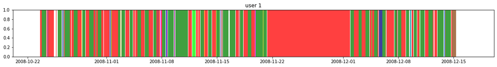

```python
user = 1
start_datetime = pd.to_datetime('2008-10-20 030000')
end_datetime = pd.to_datetime('2008-12-20 030000')
ax = cstdf.plot_diary(user, start_datetime=start_datetime, end_datetime=end_datetime)
```

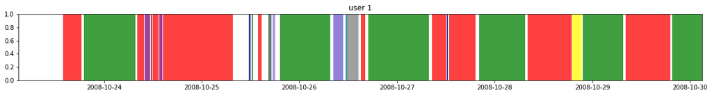

```python
user = 1
start_datetime = pd.to_datetime('2008-10-23 030000')
end_datetime = pd.to_datetime('2008-10-30 030000')
ax = cstdf.plot_diary(user, start_datetime=start_datetime, end_datetime=end_datetime)
```

## Routing

Using OSMnx and networkx (taken from https://medium.com/@bobhaffner/osmnx-intro-and-routing-1fd744ba23d8).

```python
import osmnx as ox
import folium
```

```python
start_i = 0
dt_start = cstdf.iloc[start_i]['leaving_datetime']
dt_end = cstdf.iloc[start_i + 1]['datetime']
user_id = cstdf.iloc[start_i]['uid']

dt_start, dt_end
```

[output not shown]

```python
tdf1 = ftdf[(ftdf['datetime'] >= dt_start) & \
            (ftdf['datetime'] <= dt_end) & \
            (ftdf['uid'] == user_id)]
tdf1.plot_trajectory()
```

[interactive chart not shown]

Raw GPS data

```python
G, shortest_route = tdf1.route()
```

```python
m = ox.plot_route_folium(G, shortest_route, route_color='green')
tdf1.plot_trajectory(map_f=m)
```

[interactive chart not shown]

Shortest path between origin and destination (green) and raw GPS data

## Load data

Checkin data from Brightkite, available [here](https://snap.stanford.edu/data/loc-Brightkite.html).

```python
# only load the first 10000 rows

url = "https://snap.stanford.edu/data/loc-brightkite_totalCheckins.txt.gz"
df = pd.read_csv(url, sep='\t', header=0, nrows=10000,
                 names=['user', 'check-in_time', "latitude", "longitude", "location id"]
                )
print(len(df))
df[:4]
```

```
10000
```

|  | user | check-in_time | latitude | longitude | location id |
| --- | --- | --- | --- | --- | --- |
| 0 | 0 | 2010-10-16T06:02:04Z | 39.891383 | -105.070814 | 7a0f88982aa015062b95e3b4843f9ca2 |
| 1 | 0 | 2010-10-16T03:48:54Z | 39.891077 | -105.068532 | dd7cd3d264c2d063832db506fba8bf79 |
| 2 | 0 | 2010-10-14T18:25:51Z | 39.750469 | -104.999073 | 9848afcc62e500a01cf6fbf24b797732f8963683 |
| 3 | 0 | 2010-10-14T00:21:47Z | 39.752713 | -104.996337 | 2ef143e12038c870038df53e0478cefc |

```python
df.dtypes
```

```
user               int64
check-in_time     object
latitude         float64
longitude        float64
location id       object
dtype: object
```

Create the `TrajectoryDataFrame`

```python
tdf = skmob.TrajDataFrame(df, latitude='latitude', longitude='longitude', \
                          datetime='check-in_time', user_id='user')
tdf[:4]
```

|  | uid | datetime | lat | lng | location id |
| --- | --- | --- | --- | --- | --- |
| 0 | 0 | 2010-10-16 06:02:04+00:00 | 39.891383 | -105.070814 | 7a0f88982aa015062b95e3b4843f9ca2 |
| 1 | 0 | 2010-10-16 03:48:54+00:00 | 39.891077 | -105.068532 | dd7cd3d264c2d063832db506fba8bf79 |
| 2 | 0 | 2010-10-14 18:25:51+00:00 | 39.750469 | -104.999073 | 9848afcc62e500a01cf6fbf24b797732f8963683 |
| 3 | 0 | 2010-10-14 00:21:47+00:00 | 39.752713 | -104.996337 | 2ef143e12038c870038df53e0478cefc |

Drop the column `location id`

```python
tdf.drop(columns=['location id'], inplace=True)
tdf[:4]
```

|  | uid | datetime | lat | lng |
| --- | --- | --- | --- | --- |
| 0 | 0 | 2010-10-16 06:02:04+00:00 | 39.891383 | -105.070814 |
| 1 | 0 | 2010-10-16 03:48:54+00:00 | 39.891077 | -105.068532 |
| 2 | 0 | 2010-10-14 18:25:51+00:00 | 39.750469 | -104.999073 |
| 3 | 0 | 2010-10-14 00:21:47+00:00 | 39.752713 | -104.996337 |

Sort rows by user ID and time

```python
tdf.dtypes
```

```
uid                       int64
datetime    datetime64[ns, UTC]
lat                     float64
lng                     float64
dtype: object
```

Delocalize the `datetime` column (remove timezone info)

```python
tdf['datetime'] = tdf['datetime'].dt.tz_localize(None)
tdf[:4]
```

|  | uid | datetime | lat | lng |
| --- | --- | --- | --- | --- |
| 0 | 0 | 2010-10-16 06:02:04 | 39.891383 | -105.070814 |
| 1 | 0 | 2010-10-16 03:48:54 | 39.891077 | -105.068532 |
| 2 | 0 | 2010-10-14 18:25:51 | 39.750469 | -104.999073 |
| 3 | 0 | 2010-10-14 00:21:47 | 39.752713 | -104.996337 |

```python
tdf.dtypes
```

```
uid                  int64
datetime    datetime64[ns]
lat                float64
lng                float64
dtype: object
```

## Filtering

Filter out all points with speed higher than `max_speed` km/h from the previous point.

```python
from skmob.preprocessing import filtering
```

```python
ftdf = filtering.filter(tdf, max_speed=500.)
ftdf[:4]
```

[output not shown]

```python
print('Points of the raw trajectory: %s.'%len(tdf))
print('Points of the filtered trajectory: %s.'%len(ftdf))
```

[output not shown]

## Compression

Reduce the number of points of the trajectory, preserving the structure.

```python
from skmob.preprocessing import compression
```

Merge together all points that are closer than `spatial_radius=0.2` kilometers from each other.

```python
# %%time

ctdf = compression.compress(ftdf, spatial_radius=0.2)
ctdf[:4]
```

[output not shown]

```python
print('Points of the filtered trajectory: %s.'%len(ftdf))
print('Points of the compressed trajectory: %s.'%len(ctdf))
```

[output not shown]

##### Visualise the filtered and compressed trajectories

```python
user = 1

imin = 0
imax = 100
dt_start = ftdf[ftdf['uid'] == user]['datetime'].min()
dt_end = ftdf[ftdf['uid'] == user]['datetime'].max()

filtered_tdf = ftdf[(ftdf['datetime'] >= dt_start) \
                 & (ftdf['datetime'] <= dt_end) \
                 & (ftdf['uid'] == user)]

compressed_tdf = ctdf[(ctdf['datetime'] >= dt_start) \
                  & (ctdf['datetime'] <= dt_end) \
                  & (ctdf['uid'] == user)]

filtered_tdf[:3]
```

[output not shown]

```python
map_f = filtered_tdf.plot_trajectory(weight=5, opacity=0.5, max_points=None)
compressed_tdf.plot_trajectory(map_f=map_f, max_points=None)
```

[output not shown]

## Stop detection

Identify locations where the user was stationary, i.e. if the user spend at least `minutes_for_a_stop` minutes within a distance `stop_radius` from a given point.

The new column `leaving_datetime` is added to the TrajectoryDataFrame, indicating the time when the user departs from the stop.

```python
from skmob.preprocessing import detection
```

```python
# %%time

stdf = detection.stops(ctdf, stop_radius_factor=0.95, \
            minutes_for_a_stop=20.0, spatial_radius=0.2, leaving_time=True)
stdf[:4]
```

[output not shown]

##### Visualise the compressed trajectory and the stops

Click on the stop markers to see a pop up with:

- User ID
- Coordinates of the stop (click to see the location on Google maps)
- Arrival time
- Departure time

```python
user = 1

map_f = ctdf[ctdf['uid'] == user].plot_trajectory(max_users=1, max_points=1000, hex_color=-1 )
stdf[stdf['uid'] == user].plot_stops(max_users=1, map_f=map_f, hex_color=-1, popup=False)
```

[output not shown]

## Clustering stops

Stops are clustered by spatial proximity using DBSCAN.

The new column `cluster` is added to the Stops TrajectoryDataFrame, where the value correspond to the cluster ID each stop belong to.

Clusters IDs are integers (0, 1, ...): 0 is the most visited cluster, 1 is the second most visited, ...

```python
from skmob.preprocessing import clustering
```

```python
# %%time

cstdf = clustering.cluster(stdf, cluster_radius_km=0.1, min_samples=1)
cstdf[:4]
```

[output not shown]

#### Write `TrajDataFrame` to file

- including the `tdf.parameters`
- automatically preserve the dtype of columns with time stamps (time zone info is lost though).

**Caveat**: dtypes other than `int`, `float` and `datetime` may not be identical to the original dtype after loading from a json file.

Check with `tdf.dtypes` and manually convert each column to the proper dtype, if needed.

```python
skmob.write(cstdf, './brightkite_clustered_stops.json')
```

```python
cstdf.dtypes
```

[output not shown]

```python
cstdf.parameters
```

[output not shown]

#### Load `TrajDataFrame` from file

```python
cstdf2 = skmob.read('./brightkite_clustered_stops.json')
cstdf2[:4]
```

[output not shown]

```python
cstdf2.dtypes
```

[output not shown]

```python
cstdf2.parameters
```

[output not shown]

##### Visualise the compressed trajectory and stops: stops in the same clusters have the same color.

Click on the stop markers to see a pop up with:

- User ID
- Cluster ID
- Coordinates of the stop (click to see the location on Google maps)
- Arrival time
- Departure time

```python
user = 1

# map_f = ctdf[ctdf['uid'] == 1].plot_trajectory(max_points=200, hex_color='#000000')
cstdf[stdf['uid'] == user].plot_stops(popup=True )#, map_f=map_f)
```

[output not shown]

#### Visualise a user's diary

```python
user = 1

ax = cstdf.plot_diary(user)
```

[output not shown]

```python
user = 1

start_datetime = pd.to_datetime('2009-05-1 030000')
end_datetime = pd.to_datetime('2009-05-5 030000')

ax = cstdf.plot_diary(user, start_datetime=start_datetime, end_datetime=end_datetime)
```

[output not shown]

Plot diary onto map

```python
# start_datetime = pd.to_datetime('2009-05-1 030000')
# end_datetime = pd.to_datetime('2009-05-21 030000')

selection = (ctdf['uid'] == user) & (start_datetime <= ctdf['datetime']) & ( ctdf['datetime']  <= end_datetime)
map_f = ctdf[selection].plot_trajectory(max_points=1000, hex_color='#000000')

selection = (stdf['uid'] == user) & (start_datetime <= stdf['datetime']) & ( stdf['datetime']  <= end_datetime)
map_f = cstdf[selection].plot_stops(popup=True , map_f=map_f)

map_f
```

[output not shown]

```python
user = 1

start_datetime = pd.to_datetime('2010-01-17 030000')
end_datetime = pd.to_datetime('2010-02-2 030000')

ax = cstdf.plot_diary(user, start_datetime=start_datetime, end_datetime=end_datetime)
```

[output not shown]

Plot diary onto map

```python
# start_datetime = pd.to_datetime('2009-05-1 030000')
# end_datetime = pd.to_datetime('2009-05-21 030000')

selection = (ctdf['uid'] == user) & (start_datetime <= ctdf['datetime']) & ( ctdf['datetime']  <= end_datetime)
map_f = ctdf[selection].plot_trajectory(max_points=1000, hex_color='#000000')

selection = (stdf['uid'] == user) & (start_datetime <= stdf['datetime']) & ( stdf['datetime']  <= end_datetime)
map_f = cstdf[selection].plot_stops(popup=True , map_f=map_f)

map_f
```

[output not shown]